# Manejo de datos en R

2017

## Contenido

- Estadística descriptiva o exploratoria
- Organización de la información
- Bases de datos
  - Modelos
  - Matriz de datos
- Importar datos en R
  - Valores separados por comas `csv`
  - Texto plano `txt`
  - Excel `xlsx`
- Exportar datos en R
- Manipulación de datos en R
  - Bibliotecas
  - Resumen de datos
  - Biblioteca `tidyr` y `dplyr`
  - Ejemplo con `tidyr` y `dplyr`
- Gráficos

## Estadística descriptiva

## Estadística descriptiva o exploratoria

- Tradicionalmente se ha entendido como un conjunto de herramientas, formado por coeficientes y técnicas, que tratan de resumir la información contenida en un conjunto de datos.
- Se constituye como parte fundamental de cualquier análisis estadístico complejo, en el que se empiezan a tomar decisiones que afectarían el problema de interés.
- Proporciona información sobre la estructura de la población que se estudia, indicando, por ejemplo, si ésta es simétrica, si realmente se trata de una única población o hay una superposición de poblaciones, detección de valores atípicos, etc.

## Organización de la información

- Los datos constituyen la materia prima de la Estadística, logrando establecer distintas clasificaciones en función de la forma en que éstos vengan dados.
- Se obtienen datos al realizar cualquier tipo de prueba, experimento, valoración, medición, observación.

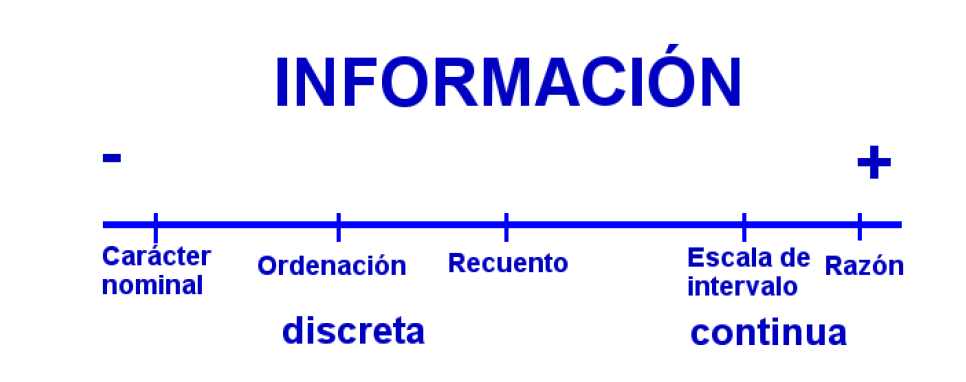

## Bases de datos

- Representación informática (o conjunto estructurado de datos) pertenecientes a un mismo contexto y almacenados sistemáticamente.
- Sistemas de gestion de bases de datos (SGBD)
  - Centralizado
  - Distribuido
  - Cliente - Servidor.

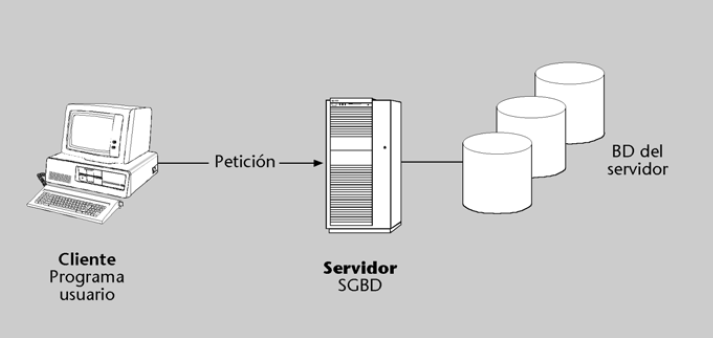

## Bases de datos

### Modelos

Un modelo de datos es una serie de conceptos que puede utilizarse para describir un conjunto de datos y las operaciones para manipularlos. Algunos de los modelos de datos son:

```
  - Base de datos jerarquica
  - Base de datos relacional
  - Base de datos de red
  - Base de datos entidad - relación
  - Base de datos multidimensional
  - Base de datos orientada a objetos
```

## Matriz de datos

- Al conjunto de individuos físicos considerados en un análisis se le denomina *Colectivo* o *Población*.
- También se utilizarán esos mismos términos para referirse a la(s) característica(s) de esos individuos que son objeto de estudio.
- `Matriz de datos:` Los datos son organizados en una matriz de \(n*p\) donde cada fila representa a un individuo o registro y las columnas a las características observadas.

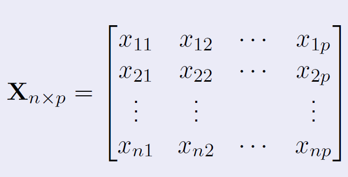

## Manipulación de datos con R

## Importar datos en R

- Lectura de datos en R:

```r
# Formato "csv"
denPoblac <- read.csv(file = "DenPobla05_10.csv", header = TRUE, sep = ",", dec = ".")

# Formato "csv2"
huevos <- read.csv2(file = "Huevos.csv", header = TRUE, sep = ";", dec = ",")

# Formato "txt"
olimpicos <- read.table(file = "ColOlimpicos.txt", header = TRUE, sep = ",", dec = ".")
```

## Exportar datos en R

- Guardar conjunto de datos en el directorio de trabajo:

```r
# Formato "csv"
write.csv(denPoblac, file = "DensidadPoblacional.csv")

# Formato "csv2"
write.csv2(olimpicos, file = "ProdHuevos.csv")

# Formato "txt"
write.table(olimpicos, file = "Olimpicos.txt")
```

## Importar y exportar Excel

- Instalar y cargar bibliotecas

```r
library(readxl)
library(xlsx)
```

- Lectura y exportación de datos:

```r
# Formato "xlsx" (Instalar previamente biblioteca "readxl")
salarios <- read_xlsx("Salarios.xlsx")

# Formato "xlsx" (Instalar previamente biblioteca "xlsx")
write.xlsx(salarios, "Salarios2.xlsx")
```

## Bibliotecas para manejo de datos

- `reshape2:` facilita la transformación de marcos de datos (data.frame) y matrices.
- `plyr`: manipulación de datos.
- `dplyr:`implementa una sintaxis en cadena (`%>%`) que da lugar a un código mucho más fácil de leer y entender que la sintaxis anidada habitual.
- `tidyr:` manipulación de datos más fácil y eficiente.

## Resumen de datos

### Densidad poblacional mundial 2005 - 2010

```r
head(denPoblac, n = 5) #Retorna los primeros 5 registros de la base de datos
```

```
##   Country.code Country.name  X2010  X2009     X2008  X2007  X2006  X2005
## 1          ABW        ARUBA 564428 563433 563022.00 562328 560167 555728
## 2          AFG  AFGHANISTAN  43549  42491  41455.00  40407  39306  38125
## 3          AGO       ANGOLA  15681  15181     14.69  14208  13734  13271
## 4          AIA     ANGUILLA 151297 149132 146868.00 144451 141791 138868
## 5          ALB      ALBANIA 109578 109614 109803.00 110137 110602 111177
```

```r
names(denPoblac)       #Retorna el nombre de las variables (columnas)
```

```
## [1] "Country.code" "Country.name" "X2010"        "X2009"
## [5] "X2008"        "X2007"        "X2006"        "X2005"
```

```r
tail(denPoblac, n = 5) #Retorna los últimos 5 registros de la base de datos
```

```
##     Country.code Country.name X2010 X2009 X2008    X2007 X2006    X2005
## 226          WSM        SAMOA 65711 65243 64798 64373.00 63961 63556.00
## 227          YEM        YEMEN 43114 42104 41108    40.12 39134 38146.00
## 228          ZAF SOUTH AFRICA 42138 41677 41168 40623.00 40064 39504.00
## 229          ZMB       ZAMBIA 17561 17041 16551    16.09 15654    15.24
## 230          ZWE     ZIMBABWE 33466 32984 32716 32604.00 32563 32528.00
```

```r
str(denPoblac)         #Retorna la estructura de un objeto R
```

```
## 'data.frame':    230 obs. of  8 variables:
##  $ Country.code: Factor w/ 230 levels "ABW","AFG","AGO",..: 1 2 3 4 5 6 7 8 9 10 ...
##  $ Country.name: Factor w/ 230 levels "AFGHANISTAN",..: 11 1 6 7 2 5 216 9 10 4 ...
##  $ X2010       : num  564428 43549 15681 151297 109578 ...
##  $ X2009       : num  563433 42491 15181 149132 109614 ...
##  $ X2008       : num  563022 41455 14.7 146868 109803 ...
##  $ X2007       : num  562328 40407 14208 144451 110137 ...
##  $ X2006       : num  560167 39306 13734 141791 110602 ...
##  $ X2005       : num  555728 38125 13271 138868 111177 ...
```

```r
dim(denPoblac)                 #Retorna la dimensión del marco de datos
```

```
## [1] 230   8
```

```r
length(denPoblac)              #Retorna la longitud del marco de datos
```

```
## [1] 8
```

```r
class(denPoblac)               #Retorna la clase atómica de "denPoblac"
```

```
## [1] "data.frame"
```

```r
class(denPoblac$Country.name)  #Retorna la clase atómica de "Country.name"
```

```
## [1] "factor"
```

```r
summary(denPoblac) #Retorna un resumen numérico del conjunto de datos
```

```
##   Country.code         Country.name     X2010              X2009
##  ABW    :  1   AFGHANISTAN   :  1   Min.   :       4   Min.   :       3
##  AFG    :  1   ALBANIA       :  1   1st Qu.:   15729   1st Qu.:   16244
##  AGO    :  1   ALGERIA       :  1   Median :   68354   Median :   68003
##  AIA    :  1   AMERICAN SAMOA:  1   Mean   :  380407   Mean   :  416609
##  ALB    :  1   ANDORRA       :  1   3rd Qu.:  181872   3rd Qu.:  173882
##  AND    :  1   ANGOLA        :  1   Max.   :24728188   Max.   :24371812
##  (Other):224   (Other)       :224
##      X2008              X2007              X2006
##  Min.   :       3   Min.   :       6   Min.   :       4
##  1st Qu.:   18338   1st Qu.:   15206   1st Qu.:   14563
##  Median :   72714   Median :   65206   Median :   64342
##  Mean   :  410848   Mean   :  374120   Mean   :  399178
##  3rd Qu.:  187676   3rd Qu.:  163087   3rd Qu.:  180998
##  Max.   :23950336   Max.   :23498658   Max.   :23066443
##
##      X2005
##  Min.   :       8
##  1st Qu.:   19266
##  Median :   69124
##  Mean   :  391460
##  3rd Qu.:  176174
##  Max.   :22689933
##
```

## Medidas estadísticas

```r
mean(denPoblac$X2010)     #Retorna la media
```

```
## [1] 380406.8
```

```r
median(denPoblac$X2010)   #Retorna la mediana
```

```
## [1] 68353.5
```

```r
min(denPoblac$X2010)      #Retorna el valor mínimo
```

```
## [1] 3.52
```

```r
max(denPoblac$X2010)      #Retorna el valor máximo
```

```
## [1] 24728188
```

```r
range(denPoblac$X2010)    #Retorna el rango
```

```
## [1]        3.52 24728188.00
```

```r
quantile(denPoblac$X2010) #Retorna los cuantiles
```

```
##          0%         25%         50%         75%        100%
##        3.52    15729.25    68353.50   181872.00 24728188.00
```

```r
sd(denPoblac$X2010)       #Retorna la desviación estándar
```

```
## [1] 2168787
```

```r
var(denPoblac$X2010)      #Retorna la varianza
```

```
## [1] 4.703637e+12
```

## Biblioteca `tidyr`

- Usos de la biblioteca `tidyr`:
  - `gather():` pasar de formato ancho a largo.
  - `spread():` pasar de formato largo a ancho.
- Verbos útiles de la biblioteca `dplyr`:
  - `select():` selecciona columnas.
  - `filter():` selecciona filas.
  - `arrange():` reordena filas.
  - `mutate():` crea o modifcia columnas.
  - `group_by():` operaciones por grupo.
  - `summarise():` resumen de datos.

## Ejemplo `tidyr - dplyr`

## Densidad poblacional mundial 2005 - 2010

```r
names(denPoblac) <- c("CodPaís","País", "2010", "2009", "2008", "2007", "2006", "2005")
names(denPoblac)
```

```
## [1] "CodPaís" "País"    "2010"    "2009"    "2008"    "2007"    "2006"
## [8] "2005"
```

```r
head(denPoblac, n = 4)
```

```
##   CodPaís        País   2010   2009      2008   2007   2006   2005
## 1     ABW       ARUBA 564428 563433 563022.00 562328 560167 555728
## 2     AFG AFGHANISTAN  43549  42491  41455.00  40407  39306  38125
## 3     AGO      ANGOLA  15681  15181     14.69  14208  13734  13271
## 4     AIA    ANGUILLA 151297 149132 146868.00 144451 141791 138868
```

```r
dim(denPoblac)
```

```
## [1] 230   8
```

## Uso de `gather()`

```r
#Pasar a formato largo
denPoblacLargo <- denPoblac %>%
                    gather(key = Año,
                           value = Densidad,
                           -c(CodPaís:País))

head(denPoblacLargo, n = 5)
```

```
##   CodPaís        País  Año Densidad
## 1     ABW       ARUBA 2010   564428
## 2     AFG AFGHANISTAN 2010    43549
## 3     AGO      ANGOLA 2010    15681
## 4     AIA    ANGUILLA 2010   151297
## 5     ALB     ALBANIA 2010   109578
```

```r
dim(denPoblacLargo)
```

```
## [1] 1380    4
```

## Uso de `spread()`

```r
#Pasar a formato ancho de nuevo
denPoblacAncho <- denPoblacLargo %>%
                    spread(key = Año,
                           value = Densidad)

head(denPoblacAncho, n = 5)
```

```
##   CodPaís        País   2005   2006   2007      2008   2009   2010
## 1     ABW       ARUBA 555728 560167 562328 563022.00 563433 564428
## 2     AFG AFGHANISTAN  38125  39306  40407  41455.00  42491  43549
## 3     AGO      ANGOLA  13271  13734  14208     14.69  15181  15681
## 4     AIA    ANGUILLA 138868 141791 144451 146868.00 149132 151297
## 5     ALB     ALBANIA 111177 110602 110137 109803.00 109614 109578
```

```r
dim(denPoblacAncho)
```

```
## [1] 230   8
```

## Uso de `select()`

```r
denPoblacSelect  <- select(denPoblac, 1:3)
denPoblacSelect2 <- select(denPoblac, CodPaís:País)
denPoblacSelect3 <- select(denPoblac, contains(c("P")))

head(denPoblacSelect, n = 1)
```

```
##   CodPaís  País   2010
## 1     ABW ARUBA 564428
```

```r
head(denPoblacSelect2, n = 1)
```

```
##   CodPaís  País
## 1     ABW ARUBA
```

```r
head(denPoblacSelect3, n = 1)
```

```
##   CodPaís  País
## 1     ABW ARUBA
```

## Uso de `filter()`

```r
denPoblacLargo2 <- denPoblacLargo %>%
                      filter(País == "COLOMBIA")

denPoblacLargo3 <- denPoblacLargo %>%
                      filter(País == c("COLOMBIA", "ECUADOR"))
```

```r
head(denPoblacLargo2, n = 6)
```

```
##   CodPaís     País  Año Densidad
## 1     COL COLOMBIA 2010    40.78
## 2     COL COLOMBIA 2009 40216.00
## 3     COL COLOMBIA 2008 39646.00
## 4     COL COLOMBIA 2007 39071.00
## 5     COL COLOMBIA 2006 38494.00
## 6     COL COLOMBIA 2005 37917.00
```

## Uso de `arrange()`

```r
denPoblacLargo4 <- denPoblacLargo %>% arrange(Densidad)
denPoblacLargo5 <- denPoblacLargo %>% arrange(-Densidad)
denPoblacLargo6 <- denPoblacLargo %>% arrange(desc(País))
```

```r
head(denPoblacLargo4, n = 3)
```

```
##   CodPaís    País  Año Densidad
## 1     NAM NAMIBIA 2009     2.60
## 2     LBY   LIBYA 2008     3.34
## 3     LBY   LIBYA 2009     3.39
```

```r
head(denPoblacLargo5, n = 3)
```

```
##   CodPaís   País  Año Densidad
## 1     MCO MONACO 2010 24728188
## 2     MCO MONACO 2009 24371812
## 3     MCO MONACO 2008 23950336
```

## Uso de `mutate()`

```r
denPoblacLargo7 <- denPoblacLargo %>% mutate(Promedio = mean(Densidad))
denPoblacLargo8 <- denPoblacLargo %>% mutate(Suma = sum(Densidad))
```

```r
head(denPoblacLargo7, n = 3)
```

```
##   CodPaís        País  Año Densidad Promedio
## 1     ABW       ARUBA 2010   564428   395437
## 2     AFG AFGHANISTAN 2010    43549   395437
## 3     AGO      ANGOLA 2010    15681   395437
```

```r
head(denPoblacLargo8, n = 3)
```

```
##   CodPaís        País  Año Densidad      Suma
## 1     ABW       ARUBA 2010   564428 545703107
## 2     AFG AFGHANISTAN 2010    43549 545703107
## 3     AGO      ANGOLA 2010    15681 545703107
```

## Uso de `group_by() - summarise()`

```r
denPoblacLargo9 <- denPoblacLargo %>%
                      group_by(País) %>%
                      summarise(Promedio = mean(Densidad))


denPoblacLargo10 <- denPoblacLargo %>%
                      group_by(Año) %>%
                      summarise(Promedio = mean(Densidad)) %>%
                      arrange(desc(Promedio))


denPoblacLargo11 <- denPoblacLargo %>%
                      group_by(Año) %>%
                      summarise(Promedio = mean(Densidad),
                                desvEst = sd(Densidad))
```

## Gráficá 1

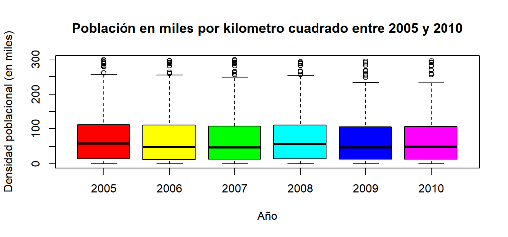

```r
denPoblacLargoF <- denPoblacLargo %>%
                      filter(Densidad/1e3 < 3e2)

boxplot(denPoblacLargoF$Densidad/1e3 ~ denPoblacLargoF$Año,
        col = rainbow(6), xlab = "Año", ylab = "Densidad poblacional (en miles)",
        main = "Población en miles por kilometro cuadrado entre 2005 y 2010")
```

## Gráficá 2

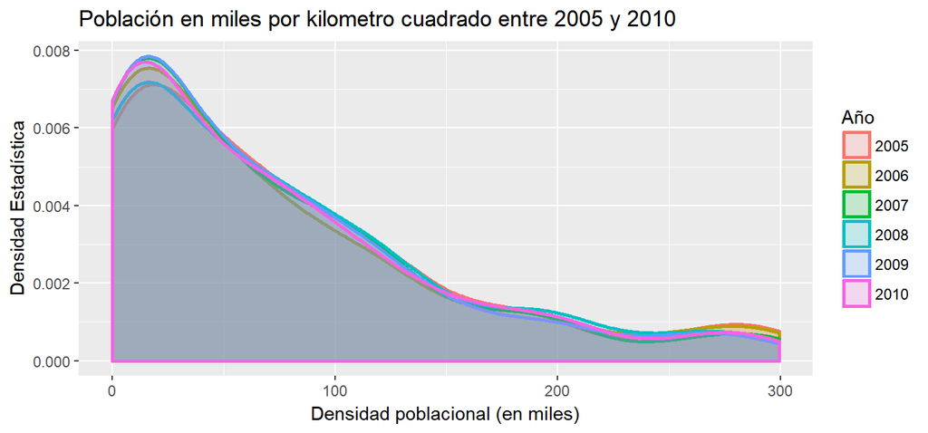

```r
ggplot(denPoblacLargoF, aes(Densidad/1e3, fill = Año, colour = Año)) +
  geom_density(alpha=0.2, lwd=0.9) +
  xlab("Densidad poblacional (en miles)") +
  ylab("Densidad Estadística") +
  labs(title = "Población en miles por kilometro cuadrado entre 2005 y 2010")
```

## Gráfica 3

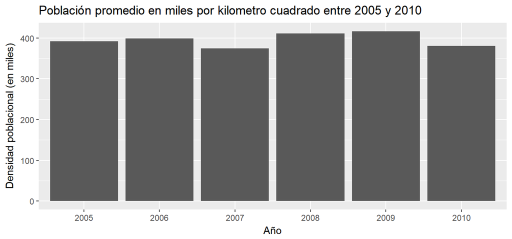

```r
ggplot(denPoblacLargo10, aes(Año, Promedio/1e3)) +
  geom_bar(stat = "identity") +
  xlab("Año") + ylab("Densidad poblacional (en miles)") +
  labs(title = "Población promedio en miles por kilometro cuadrado entre 2005 y 2010")
```